# Simulation setting

Jan Svitak, Rob van der Noll

January 28, 2020

## The simulation environment

In this notebook we present the simulation setting we use to illustrate how the mechanisms built into the selflearning algorithms could facilitate coordination on supra-competitive prices. We assume a market with two competitors offering two heterogenous but substitutable products with zero costs competing simultaneously on prices. The demand for both products follows the logit specification:
$$\log\left(s_i\right)-\log\left(1-s_i-s_j\right)=\alpha_i-\beta_i p_i$$
where $s_i$ is a volume share for firm $i$. The ‘market’ consists of the two goods of firms 1 and 2 and an outside good.

We set $\alpha_1=\alpha_2=\beta_1=\beta_2=5$ and let the firms choose simultaneously from 10 discrete prices between 0 and 1.

This allows us to calculate the profits for all combinations of prices for the two products.

```r
#set of available prices
P <- seq(0.1, 1, 0.1)
#all combinations of prices for the two competitors
P_matrix <- data.frame(x1 = rep(P, each = length(P)),
                       x2 = rep(P, length(P)))
#profit for firm 2 based on the specified logit demand
P_matrix$profit <- P_matrix$x2*exp(5 - 5*P_matrix$x2)/(1 + exp(5 - 5*P_matrix$x2) + exp(5 - 5*P_matrix$x1))
```

We can visualise the profits of Firm 2 for different combinations of prices and thereby, show what the best responses are.

```r
#save as png
png(filename="Fig4.png", width=900, height=700, pointsize = 12, res = 150)
#start a ggplot
ggplot() +
  #create tiles for all combinations of prices
  #let the tiles' colour vary with profit
  geom_tile(data = P_matrix, aes(x = x2, y = x1, fill = profit)) +
  #specify the colour palette
  scale_fill_distiller(palette = "RdYlBu") +
  #add an invisible point (shape = NA) to add a description in the legend
  geom_point(data = data.frame(x = 1, y = 1, t = "Optimale reactie"), aes(x = x, y = y, color = t), shape = NA) +
  #specify tickmarks and title of y-axis
  scale_y_continuous(
    name = "Prijs van concurrent",
    breaks = seq(0.1, 1, 0.1),
    expand = c(0, 0)
  ) +
  scale_x_continuous(
    name = "Beschikbare acties",
    breaks = seq(0.1, 1, 0.1),
    expand = c(0, 0)
  ) +
  #mark the optimal reactions
  geom_encircle(data = data.frame(x1 = rep(c(0.99, 1.01), 2),
                                  x2 = c(rep(0.69, 2), rep(0.71, 2))),
                aes(x = x2, y = x1),
                color="green2", s_shape=0.9,size=3, expand = 0.05) +
  geom_encircle(data = data.frame(x1 = rep(c(0.89, 0.91), 2),
                                  x2 = c(rep(0.59, 2), rep(0.61, 2))),
                aes(x = x2, y = x1),
                color="green2", s_shape=0.9,size=3, expand = 0.05) +
  geom_encircle(data = data.frame(x1 = rep(c(0.79, 0.81), 2),
                                  x2 = c(rep(0.59, 2), rep(0.61, 2))),
                aes(x = x2, y = x1),
                color="green2", s_shape=0.9,size=3, expand = 0.05) +
  geom_encircle(data = data.frame(x1 = rep(c(0.69, 0.71), 2),
                                  x2 = c(rep(0.49, 2), rep(0.51, 2))),
                aes(x = x2, y = x1),
                color="green2", s_shape=0.9,size=3, expand = 0.05) +
  geom_encircle(data = data.frame(x1 = rep(c(0.59, 0.61), 2),
                                  x2 = c(rep(0.49, 2), rep(0.51, 2))),
                aes(x = x2, y = x1),
                color="green2", s_shape=0.9,size=3, expand = 0.05) +
  geom_encircle(data = data.frame(x1 = rep(c(0.49, 0.51), 2),
                                  x2 = c(rep(0.39, 2), rep(0.41, 2))),
                aes(x = x2, y = x1),
                color="green2", s_shape=0.9,size=3, expand = 0.05) +
  geom_encircle(data = data.frame(x1 = rep(c(0.39, 0.41), 2),
                                  x2 = c(rep(0.39, 2), rep(0.41, 2))),
                aes(x = x2, y = x1),
                color="green2", s_shape=0.9,size=3, expand = 0.05) +
  geom_encircle(data = data.frame(x1 = rep(c(0.29, 0.31), 2),
                                  x2 = c(rep(0.39, 2), rep(0.41, 2))),
                aes(x = x2, y = x1),
                color="green2", s_shape=0.9,size=3, expand = 0.05) +
  geom_encircle(data = data.frame(x1 = rep(c(0.19, 0.21), 2),
                                  x2 = c(rep(0.29, 2), rep(0.31, 2))),
                aes(x = x2, y = x1),
                color="green2", s_shape=0.9,size=3, expand = 0.05) +
  geom_encircle(data = data.frame(x1 = rep(c(0.09, 0.11), 2),
                                  x2 = c(rep(0.29, 2), rep(0.31, 2))),
                aes(x = x2, y = x1),
                color="green2", s_shape=0.9,size=3, expand = 0.05) +
  #adjust panel background and legend key background
  theme(panel.background = element_rect(fill = NA),
        legend.key = element_blank()) +
  #set titles for colour legend and the whole figure
  labs(fill = "Winst", color = "") +
  #adjust legend
  guides(
    #create legend key for optimal reactions
    color = guide_legend(
      override.aes = list(size = 10, stroke = 2, shape = 0, color = "green2")
    ),
    #put fill to the top of the legend
    fill = guide_colourbar(order = 1)
  ) +
  #denote Nash equilibrium
  annotate("text", x = 0.4, y = 0.405, label = "Competitieve prijs", size = 3) +
  #denote Monopoly price
  annotate("text", x = 0.9, y = 0.905, label = "Collusieprijs", size = 3)
dev.off()
```

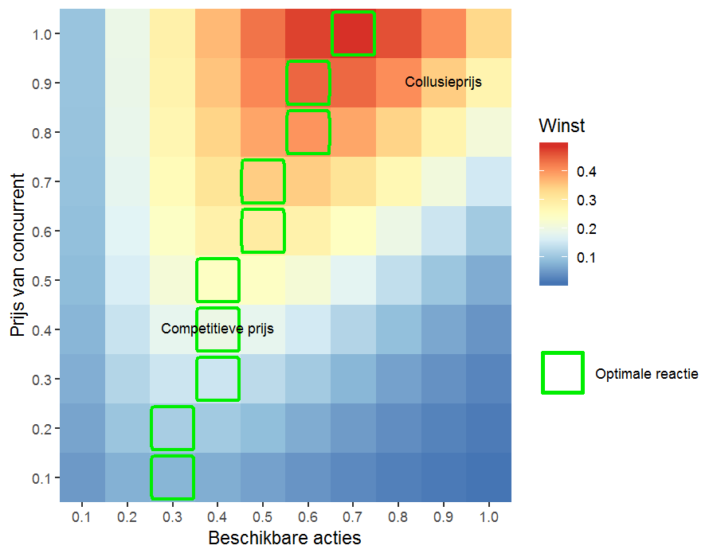

## Types of learning algorithms

Furthermore, we present schematic descriptions of the types of selflearning algorithms we use.

The simplest algorithms solve the multi-armed bandit problem, where an optimal choice needs to be identified from a set of alternatives. Only the own choices and own reward is observed by these algorithms.

```r
Fig1 <- grViz("
digraph boxes_and_circles {
  # a 'graph' statement
  graph [overlap = true, fontsize = 10]
  # several 'node' statements
  node [shape = box,
        fontname = Helvetica]
  Action; Reward
  # several 'edge' statements
  Action->Reward [minlen = 2]
  subgraph {
    rank = same; Action; Reward;
  }
}
")
capture.output(rsvg_png(charToRaw(export_svg(Fig1)), 'Fig1.png', width = 862, height = 250))
```

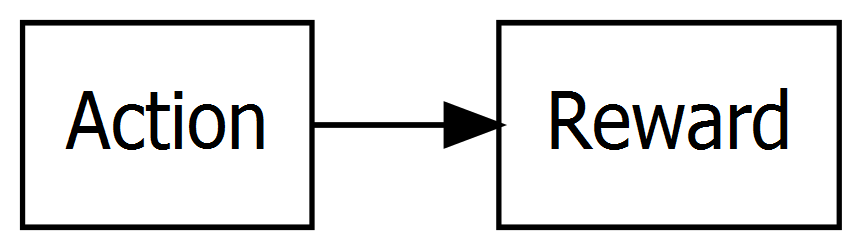

More advanced algorithms are able to recognize that the reward can also depend on the context. If reward is partly dependent on context (e.g. prices of competitor), the algorithms solve a contextual bandit problem. The algorithms now need to identify a optimal choice for each state of the world (context).

```r
Fig2 <- grViz("
digraph boxes_and_circles {
  # a 'graph' statement
  graph [overlap = true, fontsize = 10]
  # several 'node' statements
  node [shape = box,
        fontname = Helvetica]
  State; Action; Reward
  # several 'edge' statements
  Action->Reward [minlen = 2]
  State->Action [minlen = 2]
  State->Reward
  subgraph {
    rank = same; State; Action; Reward;
  }
}
")
capture.output(rsvg_png(charToRaw(export_svg(Fig2)), 'Fig2.png', width = 862, height = 250))
```

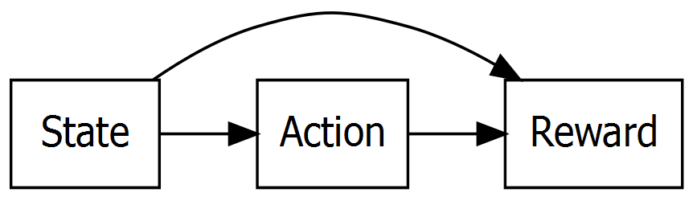

We can go one extra step further and allow the actions of the actors to influence the environment. In the case of a price-setting game, we can imagine that a price set in period $t$ can influence competitor’s strategy in period $t+1$ and thereby also rewards for both players in period $t+1$. Actors in this setting solve the reinforcement learning problem.

```r
Fig3 <- grViz("
digraph boxes_and_circles {

      # a 'graph' statement
      graph [overlap = true, fontsize = 10]

      # several 'node' statements
      node [shape = box,
      fontname = Helvetica]
      State; Action; Reward

      # several 'edge' statements
      Action->Reward [minlen = 2]
      State->Action
      State->Reward
      Action->State [minlen = 2]
      subgraph {
      rank = same; State; Action; Reward;
      }
      }
      ")
capture.output(rsvg_png(charToRaw(export_svg(Fig3)), 'Fig3.png', width = 862, height = 250))
```

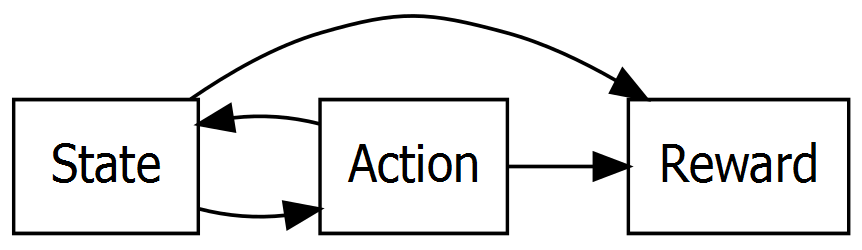